# Subset Data

## 1. Introduction

The amount of data generated by high throughput microscopy is immense. This can result in *cypro* objects containing hundreds of thousands of cells. Consider the example object below.

```r
# load packages
library(cypro)
library(tidyverse)
library(patchwork)

object_original <- readRDS(file = "data/bids-week4-big.RDS")

object_original
```

```
## An object of class 'cypro'.
##
## Name: bids-week4
## Type: One Time Imaging
## Number of Cells: 86201
## Conditions: '5-fluorouracil', 'AG-1478', 'anisomycin', 'AZ258', 'caspase inhibitor (ZVAD)', 'cyclohexamide', 'DMSO', 'indirubin monoxime', 'mitomycin C', 'neomycin', 'okadaic acid', 'olomoucine', 'taxol' and 'tunicamycin'
## Cell Lines: 'MCF7'
## Well Plates: 'Week4_27481' and 'Week4_27801'
## Variable Sets: 'intensity'
```

Even 86000 cells are enough for certain machine learning algorithms to surrender. For instance, Rs partitioning around medoids (PAM) implementation `cluster::pam()` does not work with more than 83.000 observations. Apart from computational efficiency you might want to focus on only subsets of cells, compute subcluster of a certain cluster etc. This is where you can make use of `cypros` subsetting functions:

- `subsetByCellID()`
- `subsetByCellLine()`
- `subsetByGroup()`
- `subsetByCondition()`
- `subsetByFilter()`
- `subsetByGroup()`
- `subsetByNumber()`

They allow to conveniently split the data of your experiment into sub-*cypro* objects by a variety of aspects. On top of that the subsetting functions store the history of subsets in the sub-*cypro* objects. You can therefore always trace your analysis back to the original one.

```r
printSubsetHistory(object = object_original)
```

```
## Provided cypro object has not been subsetted yet.
```

## 2. Subset by number

Having computational efficiency in mind you can reduce the number of cells by randomly selecting cells while forcing equal numbers of cells across specific groups - such as cell line and condition.

(If you are interested in analyzing proliferation and cell counts under certain conditions and treatments you should not use this function.)

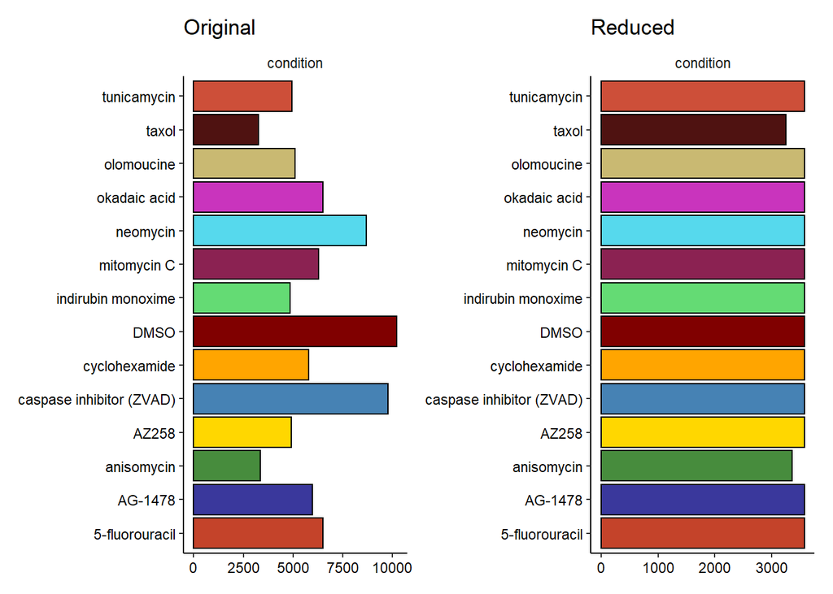

Figure 2.1 Adjustment of cell count as across was specified as ‘condition’

```r
# reduce the total number of cells to  ~ 50.000
object_reduced <-
  subsetByNumber(object_original,
                 new_name = "bids-w4-red",
                 across = "condition",
                 n_total = 50000)

# equal number of cells across conditions
plotBarchart(object_original, variables = "condition", position = "stack") +
  coord_flip() +
  ggtitle("Original") +

plotBarchart(object_reduced, variables = "condition", position = "stack") +
  coord_flip() +
  ggtitle("Reduced")
```

## 3. Subset by groups and conditions

You can create subsets according to all grouping variables your *cypro* object contains. (`subsetByCellLine()` and `subsetByCondition()` are wrapper around `subsetByGroup()`.)

```r
getGroupingVariableNames(object_reduced, verbose = F)
```

**output**

```
## [1] "cell_line"        "condition"        "concentration"    "moa"              "well_plate_name"  "well_plate_index"
## [7] "well"             "well_image"
```

For instance, create subsets by wells if they share characteristics of interest.

```r
# all wells
getGroupNames(object_reduced, grouping_variable = "well")
```

**output**

```
##  [1] "B10" "B11" "B2"  "B3"  "B4"  "B5"  "B6"  "B7"  "B8"  "B9"  "C10" "C11" "C2"  "C3"  "C4"  "C5"  "C6"  "C7"  "C8"  "C9"  "D10"
## [22] "D11" "D2"  "D3"  "D4"  "D5"  "D6"  "D7"  "D8"  "D9"  "E10" "E11" "E2"  "E3"  "E4"  "E5"  "E6"  "E7"  "E8"  "E9"  "F10" "F11"
## [43] "F2"  "F3"  "F4"  "F5"  "F6"  "F7"  "F8"  "F9"  "G10" "G11" "G2"  "G3"  "G4"  "G5"  "G6"  "G7"  "G8"  "G9"
```

```r
# b wells
b_wells <- getGroupNames(object_reduced, grouping_variable = "well", starts_with("B"))

b_wells
```

**output**

```
##  [1] "B10" "B11" "B2"  "B3"  "B4"  "B5"  "B6"  "B7"  "B8"  "B9"
```

```r
object_bwells <-
  subsetByGroup(object_reduced,
                new_name = "bids-week4-red-bwells",
                grouping_variable = "well",
                groups = b_wells)

object_bwells
```

**output**

```
## An object of class 'cypro'.
##
## Name: bids-week4-red-bwells
## Type: One Time Imaging
## Number of Cells: 8051
## Conditions: 'anisomycin', 'cyclohexamide', 'DMSO' and 'taxol'
## Cell Lines: 'MCF7'
## Well Plates: 'Week4_27481' and 'Week4_27801'
## Variable Sets: 'intensity'
```

## 4. Subset by filter

Another option would be to create a subset in style of `dplyr::filter()` by filtering for cells that match certain requirements.

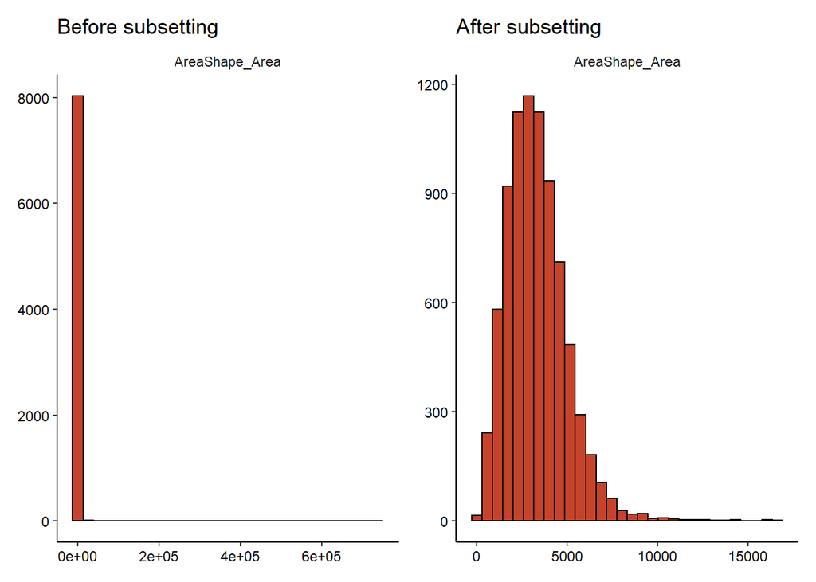

Figure 4.1 Difference in distribution before and after subsetting.

```r
# remove obviuos outlier cells
object_normal_cells <-
  subsetByFilter(object_bwells, new_name = "normal-sized", AreaShape_Area < 20000 )

plotHistogram(object_bwells, variables = "AreaShape_Area") +
  ggtitle("Before subsetting") +

plotHistogram(object_normal_cells, variables = "AreaShape_Area") +
  ggtitle("After subsetting")
```

The function `printSubsetHistory()` keeps track of the subsetting.

```r
printSubsetHistory(object_normal_cells)
```

```
##
## First Subsetting:
##
## By: Number
## Across: 'condition'
## Parent object: bids-week4
## New object: bids-w4-red
## Cells remaining: 49453
##
## --------------------------------------------------
##
## Second Subsetting:
##
## By: Group
## Grouping Name: 'well'
## Kept: 'B10', 'B11', 'B2', 'B3', 'B4', 'B5', 'B6', 'B7', 'B8' and 'B9'
## Parent object: bids-w4-red
## New object: bids-week4-red-bwells
## Cells remaining: 8051
##
## --------------------------------------------------
##
## Third Subsetting:
##
## By: Filter
## Requirements:
##  1. AreaShape_Area<20000
## Parent object: bids-week4-red-bwells
## New object: normal-sized
## Cells remaining: 8048
```